[figure not shown]

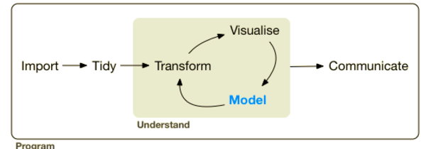

[figure not shown]

```r
library(tidyverse)
```

# **Importing Data**

### **Creating**

```r
data_frame(
  Col1 = c("a", "b", "c"),
  Col2 = c(1, 2, 3),
  Col3 = c("one", "two", "three")
  )

list_version <- l(Col1 = c("a", "b", "c"), Col2 = c(1, 2, 3), Col3 = c("one", "two", "three"))
as_data_frame(list_version)
```

### **Reading in File**

```r
library(readr)

csv_dataframe <- read_csv("datasource.csv")
tab_separated_dataframe <- read_tsv("datasource.txt")
other_separated_dataframe <- read_delim("datasource.txt", delim = "/")

set_col_types <- read_csv("datasource.csv",col_types = "cdil_cd")
# c = character, d = double (number), i = integer, l = logical, NULL = let readr guess, _ = skip

new_col_names <- c("Col1", "Col2", "Col3")
set_col_names <- read_csv("datasource", col_names = new_col_names)
```

### **Statistical Packages**

```r
library(haven)
```

```r
# SAS
read_sas("file.sas7bdat")
```

```r
# STATA
read_stata("file.dta")
```

```r
# SPSS
read_sav("file.sav")
read_por("file.por")
```

```r
file %>%
  mutate(category = as_factor(category))

file %>%
  mutate(date = as.Date(as_factor(date)))
```

### **Connecting to a Database**

```r
library(DBI)
library(RMySQL)

# Create connection
con <- dbConnect(
  RMySQL::MySQL(),
  host = "courses.csrrinzqubik.us-east-1.rds.amazonaws.com",
  dbname = "tweater",
  user = "student",
  port = 3306,
  password = getPass::getPass("Database Password")
)
```

```
## Please enter password in TK window (Alt+Tab)
```

```r
# List tables
dbListTables(con)
```

```
## [1] "comments" "tweats"   "users"
```

```r
# Read in table
df <- dbReadTable(con,"users")

head(df)
```

| id | name | login |
| --- | --- | --- |
| 1 | elisabeth | elismith |
| 2 | mike | mikey |
| 3 | thea | teatime |
| 4 | thomas | tomatotom |
| 5 | oliver | olivander |
| 6 | kate | katebenn |

```r
# Read in all tables
tables <- lapply(table_names, dbReadTable, conn = con)
```

```r
# SQL query
dbGetQuery(con,
           "SELECT *
           FROM comments
           WHERE user_id = 1")
```

| id | tweat_id | user_id | message |
| --- | --- | --- | --- |
| 1012 | 87 | 1 | awesome! thanks! |
| 1004 | 49 | 1 | this is fabulous! |
| 1020 | 77 | 1 | couldn’t be better |
| 1014 | 77 | 1 | saved my day |

```r
res <- dbSendQuery(con,
                   "SELECT *
                   FROM comments
                   WHERE user_id = 1")

dbFetch(res, n = 100)
```

```r
# Disconnect
dbDisconnect(con)
```

```
## [1] TRUE
```

### **APIs**

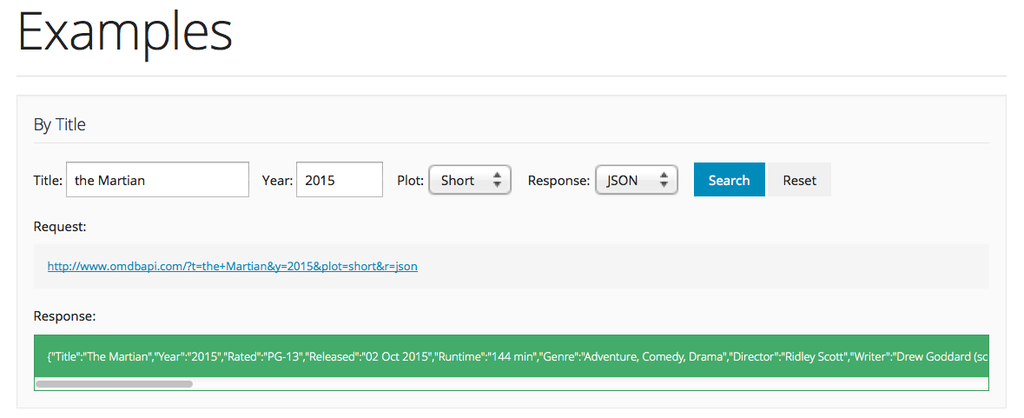

```r
library(jsonlite)

url1 <- "http://www.omdbapi.com/?apikey=13ad15a2&t=Hello+Again&y=2017&r=json"
url2 <- "http://www.omdbapi.com/?apikey=13ad15a2&t=Tristan+%26+Isolde&r=json"

movie1 <- fromJSON(url1)
movie2 <- fromJSON(url2)

movie1[c("Title", "Ratings")]
```

```
## $Title
## [1] "Hello Again"
##
## $Ratings
##                    Source  Value
## 1 Internet Movie Database 6.1/10
## 2         Rotten Tomatoes    29%
## 3              Metacritic 43/100
```

```r
movie2[c("Title", "Ratings")]
```

```
## $Title
## [1] "A Reading of Tristan & Isolde"
##
## $Ratings
##                    Source  Value
## 1 Internet Movie Database 8.2/10
```

### **Working with Excel**

```r
library(XLConnect)

# Build connection to file
my_book <- loadWorkbook("excel_file.xlsx")

# Print the names of all worksheets
getSheets(my_book)

# Read a specific sheet
df1 <- readWorksheet(my_book, sheet = 1)
df1 <- readWorksheet(my_book, sheet = 2, header = FALSE)

df_final_tall <- rbind(df1, df2)
df_final_wide <- cbind(df1, df2)

# Add a sheet
createSheet(my_book, "new_sheet")
writeWorksheet(my_book, df_from_r ,"new_sheet")

# Rename a sheet
renameSheet(my_book,"old_name","new_name")

# Delete a sheet
removeSheet(my_book,"sheet")

# Save file
saveWorkbook(my_book,"excel_file.xlsx")
```

*Since we do not have a dataset, we are going to use the gapminder data as an example.*

```r
library(gapminder)
```

[figure not shown]

# **Data Exploration**

### **Confirm it’s a Dataframe**

```r
class(gapminder)
```

```
## [1] "tbl_df"     "tbl"        "data.frame"
```

### **Check Dimensions**

```r
dim(gapminder) # Result = rows  columns
```

```
## [1] 1704    6
```

### **View Columns**

```r
colnames(gapminder)
```

```
## [1] "country"   "continent" "year"      "lifeExp"   "pop"       "gdpPercap"
```

### **Head/Tail**

```r
gapminder %>%
  head()
```

| country | continent | year | lifeExp | pop | gdpPercap |
| --- | --- | --- | --- | --- | --- |
| Afghanistan | Asia | 1952 | 28.801 | 8425333 | 779.4453 |
| Afghanistan | Asia | 1957 | 30.332 | 9240934 | 820.8530 |
| Afghanistan | Asia | 1962 | 31.997 | 10267083 | 853.1007 |
| Afghanistan | Asia | 1967 | 34.020 | 11537966 | 836.1971 |
| Afghanistan | Asia | 1972 | 36.088 | 13079460 | 739.9811 |
| Afghanistan | Asia | 1977 | 38.438 | 14880372 | 786.1134 |

### **Select Specific Columns**

There are special functions that can be used within the select function:

- starts_with(), ends_with(), contains()
- matches()
- num_range()
- one_of()
- everything()
- “-” removes a column (e.g. -Year)

```r
gapminder %>%
  select(country,year,pop) %>%
  head()
```

| country | year | pop |
| --- | --- | --- |
| Afghanistan | 1952 | 8425333 |
| Afghanistan | 1957 | 9240934 |
| Afghanistan | 1962 | 10267083 |
| Afghanistan | 1967 | 11537966 |
| Afghanistan | 1972 | 13079460 |
| Afghanistan | 1977 | 14880372 |

### **Select Specific Values**

```r
gapminder %>%
  filter(year == 2007, country == "United States")
```

| country | continent | year | lifeExp | pop | gdpPercap |
| --- | --- | --- | --- | --- | --- |
| United States | Americas | 2007 | 78.242 | 301139947 | 42951.65 |

```r
gapminder %>%
  filter(year == 2007, country == "United States" | country == "Canada")
```

| country | continent | year | lifeExp | pop | gdpPercap |
| --- | --- | --- | --- | --- | --- |
| Canada | Americas | 2007 | 80.653 | 33390141 | 36319.24 |
| United States | Americas | 2007 | 78.242 | 301139947 | 42951.65 |

```r
north_amer <- c("United States","Canada","Mexico")
gapminder %>%
  filter(year == 2007, country %in% north_amer)
```

| country | continent | year | lifeExp | pop | gdpPercap |
| --- | --- | --- | --- | --- | --- |
| Canada | Americas | 2007 | 80.653 | 33390141 | 36319.24 |
| Mexico | Americas | 2007 | 76.195 | 108700891 | 11977.57 |
| United States | Americas | 2007 | 78.242 | 301139947 | 42951.65 |

Also: `is.na()` and `!is.na()`

### **Glimpse**

```r
gapminder %>%
  glimpse()
```

```
## Observations: 1,704
## Variables: 6
## $ country   <fct> Afghanistan, Afghanistan, Afghanistan, Afghanistan, ...
## $ continent <fct> Asia, Asia, Asia, Asia, Asia, Asia, Asia, Asia, Asia...
## $ year      <int> 1952, 1957, 1962, 1967, 1972, 1977, 1982, 1987, 1992...
## $ lifeExp   <dbl> 28.801, 30.332, 31.997, 34.020, 36.088, 38.438, 39.8...
## $ pop       <int> 8425333, 9240934, 10267083, 11537966, 13079460, 1488...
## $ gdpPercap <dbl> 779.4453, 820.8530, 853.1007, 836.1971, 739.9811, 78...
```

### **Summary Statistics**

```r
gapminder %>%
  summary()
```

```
##         country        continent        year         lifeExp
##  Afghanistan:  12   Africa  :624   Min.   :1952   Min.   :23.60
##  Albania    :  12   Americas:300   1st Qu.:1966   1st Qu.:48.20
##  Algeria    :  12   Asia    :396   Median :1980   Median :60.71
##  Angola     :  12   Europe  :360   Mean   :1980   Mean   :59.47
##  Argentina  :  12   Oceania : 24   3rd Qu.:1993   3rd Qu.:70.85
##  Australia  :  12                  Max.   :2007   Max.   :82.60
##  (Other)    :1632
##       pop              gdpPercap
##  Min.   :6.001e+04   Min.   :   241.2
##  1st Qu.:2.794e+06   1st Qu.:  1202.1
##  Median :7.024e+06   Median :  3531.8
##  Mean   :2.960e+07   Mean   :  7215.3
##  3rd Qu.:1.959e+07   3rd Qu.:  9325.5
##  Max.   :1.319e+09   Max.   :113523.1
##
```

### **Summarize**

```r
gapminder %>%
  filter(year==2007) %>%
  summarize("Mean Life Expectancy" = mean(lifeExp), "Total Population" = sum(as.numeric(pop)))
```

| Mean Life Expectancy | Total Population |
| --- | --- |
| 67.00742 | 6251013179 |

```r
gapminder %>%
  filter(year==2007) %>%
  summarize("Observations" = n(), "Continents" = n_distinct(continent))
```

| Observations | Continents |
| --- | --- |
| 142 | 5 |

### **Counts**

This tells us the number of records per continent

```r
gapminder %>%
  count(continent)
```

| continent | n |
| --- | --- |
| Africa | 624 |
| Americas | 300 |
| Asia | 396 |
| Europe | 360 |
| Oceania | 24 |

This tells us the number of records per continent per year

```r
gapminder %>%
  filter(year>2000) %>%
  count(continent, year)
```

| continent | year | n |
| --- | --- | --- |
| Africa | 2002 | 52 |
| Africa | 2007 | 52 |
| Americas | 2002 | 25 |
| Americas | 2007 | 25 |
| Asia | 2002 | 33 |
| Asia | 2007 | 33 |
| Europe | 2002 | 30 |
| Europe | 2007 | 30 |
| Oceania | 2002 | 2 |
| Oceania | 2007 | 2 |

This tells us how many countries there are per continent

```r
gapminder %>%
  count(continent, country) %>%
  count(continent)
```

| continent | nn |
| --- | --- |
| Africa | 52 |
| Americas | 25 |
| Asia | 33 |
| Europe | 30 |
| Oceania | 2 |

### **Visualizing**

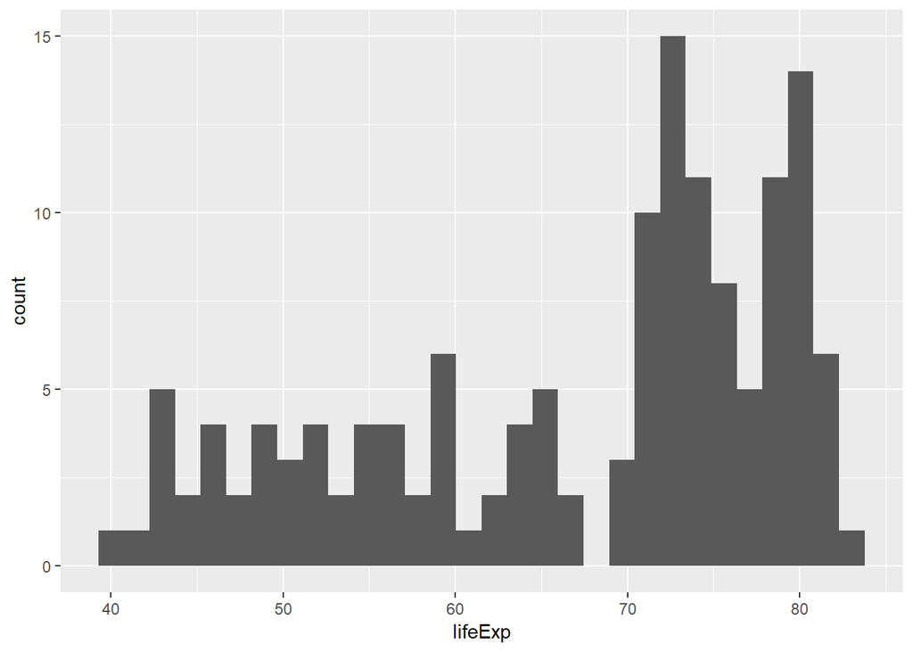

```r
gapminder %>%
  filter(year == 2007) %>%
  ggplot(aes(lifeExp)) + geom_histogram()
```

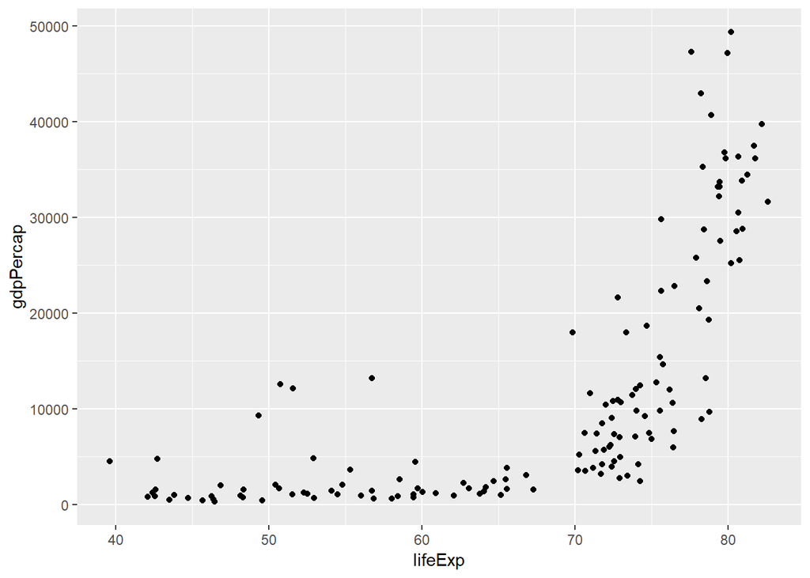

```r
gapminder %>%
  filter(year == 2007) %>%
  ggplot(aes(lifeExp, gdpPercap)) + geom_point()
```

### **Correlation Table**

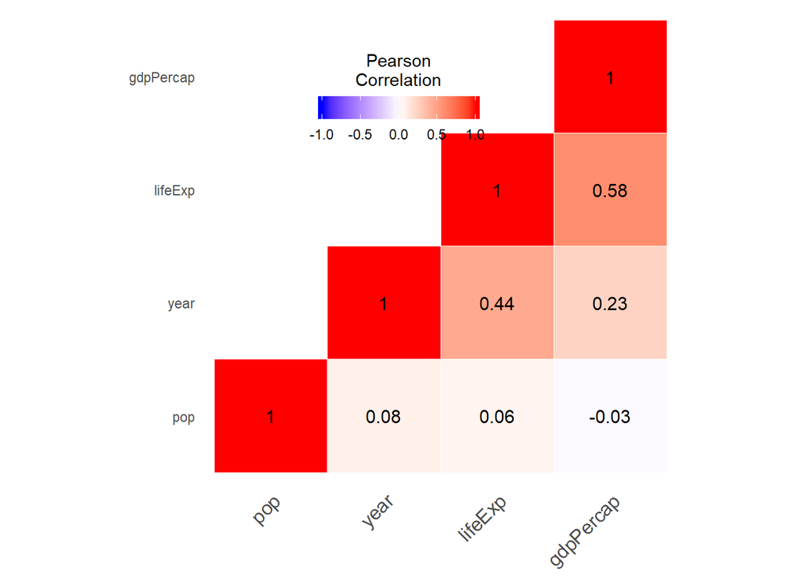

[figure not shown]

```r
library(reshape2)

get_pretty_cormap <- function (.data, .numcols) {
  cormat <- round(cor(select(.data, .numcols)), 2)

  reorder_cormat <- function(cormat){
    dd <- as.dist((1-cormat)/2)
    hc <- hclust(dd)
    cormat <-cormat[hc$order, hc$order]}
  cormat <- reorder_cormat(cormat)

  get_upper_tri <- function(cormat){
    cormat[lower.tri(cormat)]<- NA
    return(cormat)}
  upper_tri <- get_upper_tri(cormat)

  melted_cormat <- melt(upper_tri, na.rm = TRUE)

  ggplot(melted_cormat, aes(Var2, Var1, fill = value)) +
    geom_tile(color = "white") +
    scale_fill_gradient2(low = "blue", high = "red", mid = "white", midpoint = 0, limit = c(-1,1),
                         space = "Lab", name = "Pearson\nCorrelation") +
    theme_minimal() +
    theme(axis.text.x = element_text(angle = 45, vjust = 1, size = 12, hjust = 1)) +
    coord_fixed() +
    geom_text(aes(Var2, Var1, label = value), color = "black", size = 4) +
    theme(axis.title.x = element_blank(),
          axis.title.y = element_blank(),
          panel.grid.major = element_blank(),
          panel.border = element_blank(),
          panel.background = element_blank(),
          axis.ticks = element_blank(),
          legend.justification = c(1, 0),
          legend.position = c(0.6, 0.7),
          legend.direction = "horizontal") +
    guides(fill = guide_colorbar(barwidth = 7, barheight = 1, title.position = "top", title.hjust = 0.5))}

get_pretty_cormap(gapminder, c("year", "lifeExp", "pop", "gdpPercap"))
```

# **Data Wrangling**

### **Tidy Data**

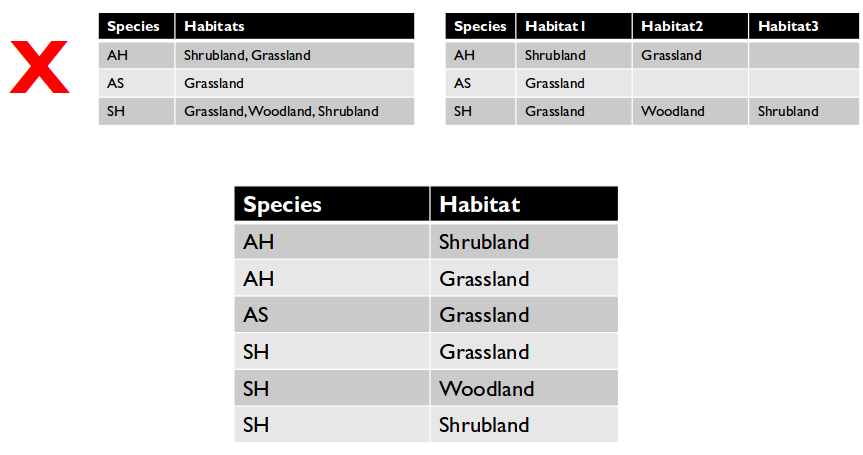

#### *- Gathering*

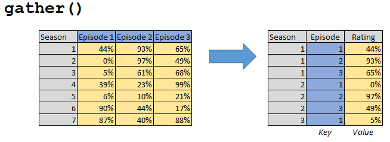

```r
dataframe %>%
  gather(key = key_name, value = value_name, -index, factor_key = TRUE)

ratings %>%
  gather(key = Episode, value = Rating, -Season, factor_key = TRUE)
```

#### *- Spreading*

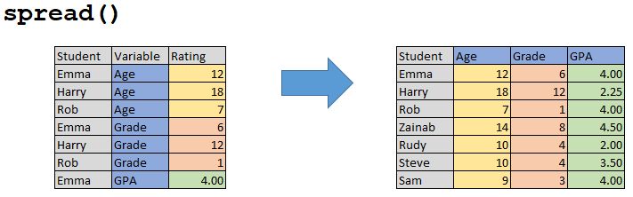

```r
dataframe %>%
  spread(key = key_name, value = value_name, convert = TRUE)

roster %>%
  gather(key = Variable, value = Rating, factor_key = TRUE)
```

### **Columns**

#### *- Mutate*

```r
gapminder %>%
  mutate(pop = pop / 1000000,          # Editing existing column
         gdp = gdpPercap * pop) %>%    # creating new column
  head(3)
```

| country | continent | year | lifeExp | pop | gdpPercap | gdp |
| --- | --- | --- | --- | --- | --- | --- |
| Afghanistan | Asia | 1952 | 28.801 | 8.425333 | 779.4453 | 6567.086 |
| Afghanistan | Asia | 1957 | 30.332 | 9.240934 | 820.8530 | 7585.449 |
| Afghanistan | Asia | 1962 | 31.997 | 10.267083 | 853.1007 | 8758.856 |

#### *- Renaming*

```r
gapminder %>%
  rename(population = pop) %>%
  head(3)
```

| country | continent | year | lifeExp | population | gdpPercap |
| --- | --- | --- | --- | --- | --- |
| Afghanistan | Asia | 1952 | 28.801 | 8425333 | 779.4453 |
| Afghanistan | Asia | 1957 | 30.332 | 9240934 | 820.8530 |
| Afghanistan | Asia | 1962 | 31.997 | 10267083 | 853.1007 |

#### *- Separating*

```r
gapminder %>%
  separate(col = lifeExp, into = c("Year", "Months"), sep = "[.]") %>%
  head(3)
```

| country | continent | year | Year | Months | pop | gdpPercap |
| --- | --- | --- | --- | --- | --- | --- |
| Afghanistan | Asia | 1952 | 28 | 801 | 8425333 | 779.4453 |
| Afghanistan | Asia | 1957 | 30 | 332 | 9240934 | 820.8530 |
| Afghanistan | Asia | 1962 | 31 | 997 | 10267083 | 853.1007 |

#### *- Uniting*

```r
gapminder %>%
  unite(location, country, continent, sep = ", ") %>%
  head(3)
```

| location | year | lifeExp | pop | gdpPercap |
| --- | --- | --- | --- | --- |
| Afghanistan, Asia | 1952 | 28.801 | 8425333 | 779.4453 |
| Afghanistan, Asia | 1957 | 30.332 | 9240934 | 820.8530 |
| Afghanistan, Asia | 1962 | 31.997 | 10267083 | 853.1007 |

### **Arranging**

#### *- Ascending*

```r
gapminder %>%
  arrange(gdpPercap) %>%
  head(3)
```

| country | continent | year | lifeExp | pop | gdpPercap |
| --- | --- | --- | --- | --- | --- |
| Congo, Dem. Rep. | Africa | 2002 | 44.966 | 55379852 | 241.1659 |
| Congo, Dem. Rep. | Africa | 2007 | 46.462 | 64606759 | 277.5519 |
| Lesotho | Africa | 1952 | 42.138 | 748747 | 298.8462 |

#### *- Descending*

```r
gapminder %>%
  arrange(desc(gdpPercap)) %>%
  head(3)
```

| country | continent | year | lifeExp | pop | gdpPercap |
| --- | --- | --- | --- | --- | --- |
| Kuwait | Asia | 1957 | 58.033 | 212846 | 113523.1 |
| Kuwait | Asia | 1972 | 67.712 | 841934 | 109347.9 |
| Kuwait | Asia | 1952 | 55.565 | 160000 | 108382.4 |

### **Recasting Data Type**

#### *- Simple Conversion*

```r
as.character(8484.01)
```

```
## [1] "8484.01"
```

```r
as.numeric("8484.01")
```

```
## [1] 8484.01
```

```r
as.integer(99)
```

```
## [1] 99
```

```r
as.logical("FALSE")
```

```
## [1] FALSE
```

#### *- Factors*

```r
gap_07 <- gapminder %>%
  filter(year==2007) %>%
  mutate(country_size =
           case_when(
             pop > 3.121e+07 ~ "large",
             pop < 4.508e+06 ~ "small",
             TRUE ~ "average"
             )
          )

str(gap_07$country_size)
```

```
##  chr [1:142] "large" "small" "large" "average" "large" "average" ...
```

```r
# Setting factor
gap_07 <- gap_07 %>%
  mutate(country_size = as.factor(country_size))

str(gap_07$country_size)
```

```
##  Factor w/ 3 levels "average","large",..: 2 3 2 1 2 1 1 3 2 1 ...
```

```r
# Setting ordered levels
gap_07 <- gap_07 %>%
  mutate(country_size = factor(country_size, levels=c("small","average","large"), ordered = TRUE))

str(gap_07$country_size)
```

```
##  Ord.factor w/ 3 levels "small"<"average"<..: 3 1 3 2 3 2 2 1 3 2 ...
```

```r
levels(gap_07$country_size)
```

```
## [1] "small"   "average" "large"
```

#### *- Dates*

*Also see the R Basics for more on dates*

- `y` = year
- `m` = month
- `d` = day
- `_` = splits date from time
- `h` = hour
- `m` = minute
- `s` = second

```r
library(lubridate)

dmy("17 Sep 2015")
```

```
## [1] "2015-09-17"
```

```r
mdy_hm("July 15, 2012 12:56")
```

```
## [1] "2012-07-15 12:56:00 UTC"
```

### **Recoding Values**

```r
dateframe <- dataframe %>%
  mutate(char_col = recode(char_col, "old" = "new"),
         num_col = recode(num_col, `100` = 10),
         multi_col = recode(multi_col, "old1" = "new1", "old2" = "new2"),
         default_col = recorde(default_col, "old1" = "new1", "old2" = "new2", .default = "everything else")
```

```r
library(hflights)
hflights %>% count(UniqueCarrier)
```

| UniqueCarrier | n |
| --- | --- |
| AA | 3244 |
| AS | 365 |
| B6 | 695 |
| CO | 70032 |
| DL | 2641 |
| EV | 2204 |
| F9 | 838 |
| FL | 2139 |
| MQ | 4648 |
| OO | 16061 |
| UA | 2072 |
| US | 4082 |
| WN | 45343 |
| XE | 73053 |
| YV | 79 |

```r
airline_lookup_table <- c("AA" = "American",
                          "AS" = "Alaska",
                          "B6" = "JetBlue",
                          "CO" = "Continental",
                          "DL" = "Delta",
                          "OO" = "SkyWest",
                          "UA" = "United",
                          "US" = "US_Airways",
                          "WN" = "Southwest",
                          "EV" = "Atlantic_Southeast",
                          "F9" = "Frontier",
                          "FL" = "AirTran",
                          "MQ" = "American_Eagle",
                          "XE" = "ExpressJet", "YV" = "Mesa")

hflights %>%
  mutate(UniqueCarrier = airline_lookup_table[UniqueCarrier]) %>%
  count(UniqueCarrier)
```

| UniqueCarrier | n |
| --- | --- |
| AirTran | 2139 |
| Alaska | 365 |
| American | 3244 |
| American_Eagle | 4648 |
| Atlantic_Southeast | 2204 |
| Continental | 70032 |
| Delta | 2641 |
| ExpressJet | 73053 |
| Frontier | 838 |
| JetBlue | 695 |
| Mesa | 79 |
| SkyWest | 16061 |
| Southwest | 45343 |
| United | 2072 |
| US_Airways | 4082 |

### **Cases**

```r
gapminder %>%
  mutate(size = case_when(
    pop > 1.959e+07 ~ "Large",
    pop < 2.794e+06 ~ "Small",
    TRUE ~ "Middle")) %>%
  filter(year==2007) %>%
  head(3)
```

| country | continent | year | lifeExp | pop | gdpPercap | size |
| --- | --- | --- | --- | --- | --- | --- |
| Afghanistan | Asia | 2007 | 43.828 | 31889923 | 974.5803 | Large |
| Albania | Europe | 2007 | 76.423 | 3600523 | 5937.0295 | Middle |
| Algeria | Africa | 2007 | 72.301 | 33333216 | 6223.3675 | Large |

### **String Manipulation**

#### *- Trim leading and trailing white space*

```r
str_trim("  this is a test     ")
```

```
## [1] "this is a test"
```

#### *- Pad with zeros*

```r
county_codes <- c("1", "51", "201")
str_pad(county_codes, width = 3, side = "left", pad = "0")
```

```
## [1] "001" "051" "201"
```

#### *- Extract just numbers*

```r
parse_number("$1,234,567")
```

```
## [1] 1234567
```

#### *- Find and replace*

```r
str_replace("bananas","a","o")
```

```
## [1] "bonanas"
```

```r
str_replace_all("bananas","a","o")
```

```
## [1] "bononos"
```

```r
str_remove("bananas","a")
```

```
## [1] "bnanas"
```

```r
str_remove_all("bananas","a")
```

```
## [1] "bnns"
```

#### *- Case*

```r
tolower("NEW YORK")
```

```
## [1] "new york"
```

```r
toupper("new york")
```

```
## [1] "NEW YORK"
```

```r
simpleCap <- function(x) {
  s <- strsplit(x, " ")[[1]]
  paste(toupper(substring(s, 1,1)), substring(s, 2),
      sep="", collapse=" ")
}

simpleCap("new york")
```

```
## [1] "New York"
```

### **Missing Values**

#### *- Set what counts as missing*

```r
dataframe <- read_csv("datasource.csv", na = c("", "NA", "UNKNOWN","etc."))

dataframe$column[dataframe$column == ""] <- NA

dateframe <- dataframe %>%
  mutate(char_col = recode(char_col, "forgot" = NA_character_),
        num_col = recode(num_col, "forgot" = NA_integer_))
```

#### *- Check for missing*

```r
any(is.na(dataframe))
any(is.na(dataframe$column))
```

#### *- Count missing*

```r
sum(is.na(dataframe))
```

#### *- Find/select missing values*

```r
dataframe %>%
  filter(is.na(column))
```

#### *- Find/select non-missing values*

```r
dataframe %>%
  filter(!is.na(column))
```

#### *- Remove missing values at any point*

```r
dataframe <- na.omit(dataframe)
```

### **Duplicates**

```r
# Drop identical rows
data %>%
  distinct()
```

### **Outliers**

Causes:

- Valid measurements that happen to be extreme
- Variability in measurement
- Experimental error
- Data entry error

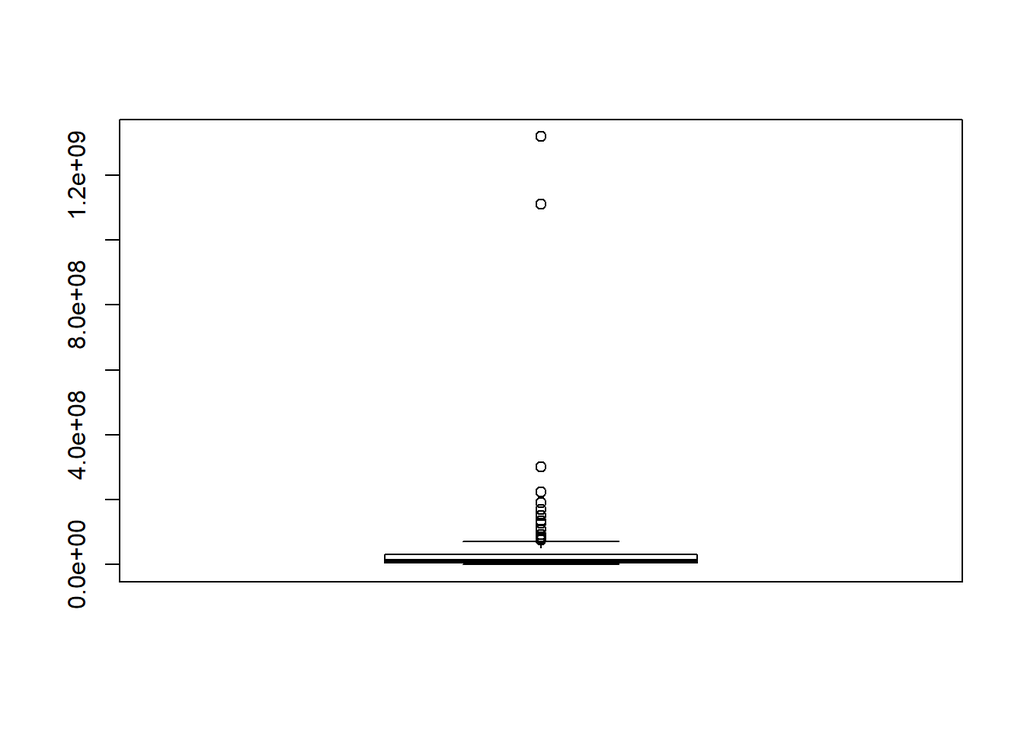

```r
boxplot(gap_07$pop)
```

All of the circles are outliers. We know that the two extremes (China and India) are, in fact, correct. If there was a third, it would be an error that should be removed or replaced. Similarly, if there was a negative, that would also be an error that should be removed or replaced.

### **Joining**

- `inner_join()`
- `full_join()`
- `left_join()`
- `right_join()`

```r
# Basic
joined_data <- data1 %>%
  inner_join(data2, by = "common_col")

# Multiple keys
joined_data <- data1 %>%
  inner_join(data2, by = c("common_col1", "common_col2")

# Key with different name
joined_data <- data1 %>%
  inner_join(data2, by = c("col from df1" = "col from df2"))
```

### **Filter Joins**

*Returns data from only one dataset based on the contents of a second dataset*

```r
# Semi join (returns data from "all data" for cases in "relevant_key")
relevant_cases <- all_data %>%
  semi_join(relevent_key, by = "common_col")

# Anti join (returns data from "all data" for cases not in "relevant_key")
relevant_cases <- all_data %>%
  anti_join(relevent_key, by = "common_col")
```

### **Set Operation**

*For when the columns are the same*

```r
# All
part1 %>%
  union(part2)

# Common
person1 %>%
  intersect(person2)

# Different (first dataset as compared to second)
too_many %>%
  setdiff(already_done)
```

### **Binds**

```r
# Columns
cols123 %>%
  bind_cols(cols456)

# Rows
rows123 %>%
  bind_rows(rows456)

# Identify source in a new column
bind_rows(top = df1, bottom = df2, .id = "source")

# Combine multiple
cols123 %>%
  bind_cols(c(cols456, cols789))
```

### **Grouping**

```r
gapminder %>%
  group_by(year) %>%
  summarize("Mean Life Expectancy" = mean(lifeExp), "Total Population" = sum(as.numeric(pop)))
```

| year | Mean Life Expectancy | Total Population |
| --- | --- | --- |
| 1952 | 49.05762 | 2406957150 |
| 1957 | 51.50740 | 2664404580 |
| 1962 | 53.60925 | 2899782974 |
| 1967 | 55.67829 | 3217478384 |
| 1972 | 57.64739 | 3576977158 |
| 1977 | 59.57016 | 3930045807 |
| 1982 | 61.53320 | 4289436840 |
| 1987 | 63.21261 | 4691477418 |
| 1992 | 64.16034 | 5110710260 |
| 1997 | 65.01468 | 5515204472 |
| 2002 | 65.69492 | 5886977579 |
| 2007 | 67.00742 | 6251013179 |

```r
gapminder %>%
  group_by(year, continent) %>%
  filter(year>2000) %>%
  summarize("Mean Life Expectancy" = mean(lifeExp), "Total Population" = sum(as.numeric(pop)))
```

| year | continent | Mean Life Expectancy | Total Population |
| --- | --- | --- | --- |
| 2002 | Africa | 53.32523 | 833723916 |
| 2002 | Americas | 72.42204 | 849772762 |
| 2002 | Asia | 69.23388 | 3601802203 |
| 2002 | Europe | 76.70060 | 578223869 |
| 2002 | Oceania | 79.74000 | 23454829 |
| 2007 | Africa | 54.80604 | 929539692 |
| 2007 | Americas | 73.60812 | 898871184 |
| 2007 | Asia | 70.72848 | 3811953827 |
| 2007 | Europe | 77.64860 | 586098529 |
| 2007 | Oceania | 80.71950 | 24549947 |

### **Ranking**

#### *- Lowest to Highest*

```r
gapminder %>%
  group_by(year) %>%
  mutate(rank = rank(lifeExp)) %>%
  ungroup() %>%
  filter(rank == 1) %>%
  select(year, country, lifeExp)
```

| year | country | lifeExp |
| --- | --- | --- |
| 1952 | Afghanistan | 28.801 |
| 1957 | Afghanistan | 30.332 |
| 1962 | Afghanistan | 31.997 |
| 1967 | Afghanistan | 34.020 |
| 1987 | Angola | 39.906 |
| 1977 | Cambodia | 31.220 |
| 1992 | Rwanda | 23.599 |
| 1997 | Rwanda | 36.087 |
| 1972 | Sierra Leone | 35.400 |
| 1982 | Sierra Leone | 38.445 |
| 2007 | Swaziland | 39.613 |
| 2002 | Zambia | 39.193 |

#### *- Highest to Lowest*

```r
gapminder %>%
  group_by(year) %>%
  mutate(rank = rank(-lifeExp)) %>%
  ungroup() %>%
  filter(rank == 1) %>%
  select(year, country, lifeExp)
```

| year | country | lifeExp |
| --- | --- | --- |
| 1957 | Iceland | 73.470 |
| 1962 | Iceland | 73.680 |
| 1977 | Iceland | 76.110 |
| 1982 | Japan | 77.110 |
| 1987 | Japan | 78.670 |
| 1992 | Japan | 79.360 |
| 1997 | Japan | 80.690 |
| 2002 | Japan | 82.000 |
| 2007 | Japan | 82.603 |
| 1952 | Norway | 72.670 |
| 1967 | Sweden | 74.160 |
| 1972 | Sweden | 74.720 |

### **Mapping**

`map(.x, .f, ...)` maps function `.f` over data `.x` using `...` additional arguments

- If `.x` is a dataframe, `.f` is mapped over each column
- If `.x` is a list or vector, `.f` is mapped over each item

`map()` returns a list  
`map_dbl()` returns a double vector  
`map_lgl()` returns a logical vector  
`map_int()` returns an integer vector  
`map_chr()` returns a character vector

`map(.x, ~ sum(.)/2)` maps a function (sum(.x)/2) on the fly

`map(.x, safely(.f))` prevents an error from ending the map function

- `results <- map(.x, safely(.f))` (a list of value and error for each item in .x)
- `values <- transpose(results)[["result"]]`
- `errors` <- transpose(results)[[“error”]]
- `is_ok <- map_lgl(errors,is_null)
- `success_results <- values[is_ok]`
- `proplem_inputs <- .x[!is_ok]`

```
pmap(list(arg1 = list(1,2,3),
          arg2 = list(4,5,6),
          arg3 = list(7,8,9)), .f)
```

This evaluates f(1,4,7), f(2,5,8), and f(3,6,9)

```
invoke_map(list(f1,f2,f3), .x)
invoke_map(list(f1 = .f1,f2 = .f2, f3 = .f3), list(f1 = list(f1 args), f2 = list(f2 args), f3 = list(f3 args)), .x)
```

This evaluates f1(.x), f2(.x), and f3(.x)

```r
x <- c(1,2,3,NA_real_)
funs <- list(Mean = "mean", Max = "max", Missing = "is.na")
params <- list(Mean = list(na.rm = TRUE),
                Max = list(na.rm = TRUE),
                Missing = list())

invoke_map(funs, params, x)
```

```
## $Mean
## [1] 2
##
## $Max
## [1] 3
##
## $Missing
## [1] FALSE FALSE FALSE  TRUE
```

`walk(.x, .f)` does the “side effect” (e.g. print, plot, save) instead of generating an outcome

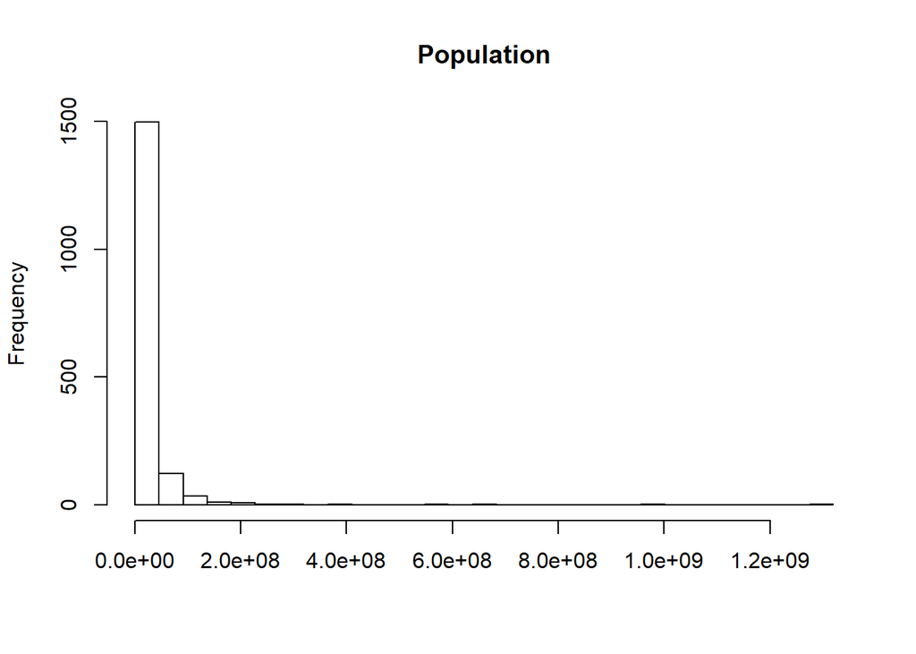

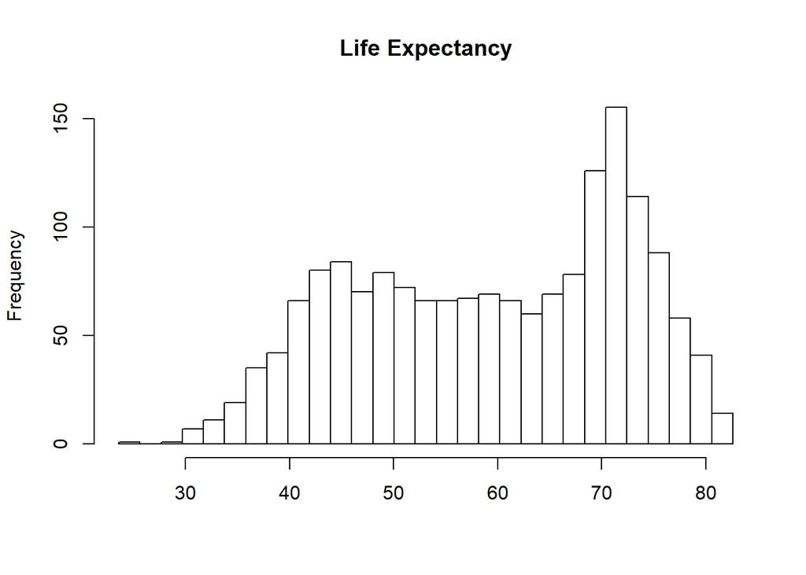

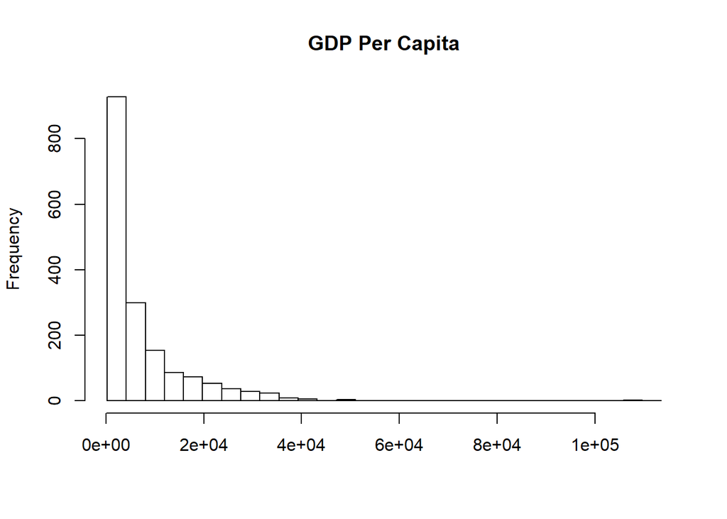

```r
val1 <- list(gapminder$pop)
val2 <- list(gapminder$lifeExp)
val3 <- list(gapminder$gdpPercap)
cols <- c(val1,val2,val3)

find_breaks <- function(x){
  rng <- range(x, na.rm = TRUE)
  seq(rng[1], rng[2], length.out = 30)
}

nice_breaks <- map(cols, find_breaks)
nice_titles <- c("Population", "Life Expectancy", "GDP Per Capita")

pwalk(list(x = cols, breaks = nice_breaks, main = nice_titles), hist, xlab = "")
```